# Project 1 Notebook

### Dataset used: tmdb-movies.csv

## Questions:

- Has the average popularity in movies increased or decreased in subsequent years?
- What factors are most likely to influence the popularity of a movie

## Wrangling

1. Aquisition : Locally stored File 'tmdb-movies.csv' provided by Udacity
2. Cleaning

```python
import pandas as pd
import unicodecsv
import numpy as np
from datetime import datetime as dt
import matplotlib.pyplot as plt
import seaborn as sns

plt.rcParams['figure.figsize'] = [12, 8]
```

##### Checking for error-prone Default Data

The original Data (which I've ommited) shows almost 600 movie titles that were reused over the years we cannot use the original_title to search and analyze our data. We also need to clean up the id, because though that is almost unique, there was a rogue repeat (Tekken) in the middle.

### Aquiring and Cleaning Data

##### Aquire main Dataset in Pandas, Print a few relevant stats I'm interested in

```python
fpath = 'tmdb-movies.csv'

column_subset = [
    'id',
    'vote_count',
    'vote_average',
    'release_year',
    'release_date',
    'budget_adj',
    'revenue_adj',
    'original_title',
    'keywords'

]

pd_data = pd.read_csv(fpath, usecols=column_subset)
print(len(pd_data))
print(len(pd_data['id'].unique()))
print(len(pd_data['original_title'].unique()))
```

```
10866
10865
10571
```

```python
#pd_data
pd_data.describe()
```

|  | id | vote_count | vote_average | release_year | budget_adj | revenue_adj |
| --- | --- | --- | --- | --- | --- | --- |
| count | 10866.000000 | 10866.000000 | 10866.000000 | 10866.000000 | 1.086600e+04 | 1.086600e+04 |
| mean | 66064.177434 | 217.389748 | 5.974922 | 2001.322658 | 1.755104e+07 | 5.136436e+07 |
| std | 92130.136561 | 575.619058 | 0.935142 | 12.812941 | 3.430616e+07 | 1.446325e+08 |
| min | 5.000000 | 10.000000 | 1.500000 | 1960.000000 | 0.000000e+00 | 0.000000e+00 |
| 25% | 10596.250000 | 17.000000 | 5.400000 | 1995.000000 | 0.000000e+00 | 0.000000e+00 |
| 50% | 20669.000000 | 38.000000 | 6.000000 | 2006.000000 | 0.000000e+00 | 0.000000e+00 |
| 75% | 75610.000000 | 145.750000 | 6.600000 | 2011.000000 | 2.085325e+07 | 3.369710e+07 |
| max | 417859.000000 | 9767.000000 | 9.200000 | 2015.000000 | 4.250000e+08 | 2.827124e+09 |

##### Clean Data

```python
print(len(pd_data['id']))
pd_data.drop_duplicates(subset=['id'], inplace=True)
print(len(pd_data['id']))
```

```
10866
10865
```

```python
pd_data['release_date'] = pd_data['release_date'].astype('datetime64[ns]')
pd_data['keywords'] = pd_data['keywords'].astype('str')
```

- Dropped Columns that did not contribute to the data I'm trying to explore
- changed 'release_date' to a datetime so I can explore how time of year affects revenue
- Change 'keywords' to a string, to allow it to be split; if I don't do this I receive an error because without the explicit cast pandas sees 'keywords' as a float

```
5696
```

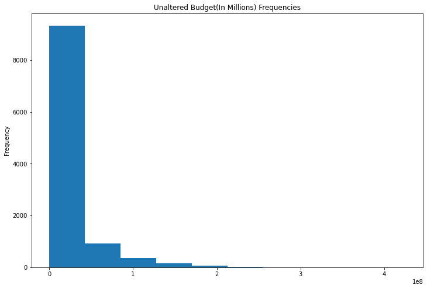

```python
print((pd_data['budget_adj'] == 0).sum(axis=0))
pd_data['budget_adj'].plot(kind='hist', title='Unaltered Budget(In Millions) Frequencies')
```

I made the decision to remove a large section of my dataset, as 0 budget movies act as a large modifier to subsequent analysis

```
id                5169
original_title    5169
keywords          5169
release_date      5169
vote_count        5169
vote_average      5169
release_year      5169
budget_adj        5169
revenue_adj       5169
dtype: int64
```

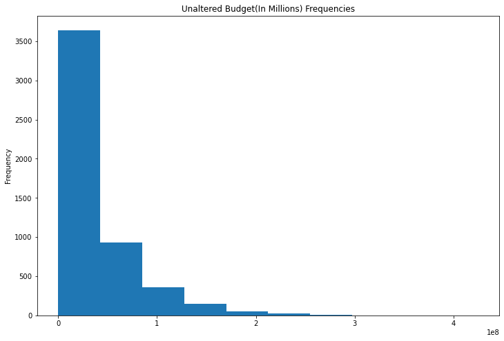

```python
df = pd_data.loc[~((pd_data['budget_adj'] == 0))]
df['budget_adj'].plot(kind='hist', title='Unaltered Budget(In Millions) Frequencies')
print(df.count())
```

#### Create Functions

```python
def standardize_col(col):
    return (col - col.mean()) / col.std()

def diff(a,b):
    return a - b
def ratio(t,p):
    return p / t

def pearsonsr(x,y):
    std_x= (x-x.mean())/x.std(ddof=0)
    std_y= (y-y.mean())/y.std(ddof=0)

    return (std_x * std_y).mean()
```

#### Create DataFrames

```python
vote_avg_by_year = df.groupby('release_year').mean()['vote_average']
release_count_by_year = df.groupby('release_year').count()['id']
year_avg_df = pd.concat([vote_avg_by_year,release_count_by_year, standardize_col(vote_avg_by_year)], axis=1)
year_avg_df.columns = ['vote_average', 'movie_count', 'avg_standard_dev']

movie_revenue_by_year = df.groupby('release_year')['revenue_adj'].mean()
movie_budget_by_year = df.groupby('release_year')['budget_adj'].mean()
movie_gross_by_year = df.groupby('release_year')['revenue_adj'].mean()-df.groupby('release_year')['budget_adj'].mean()
movie_ratio_by_year = df.groupby('release_year')['revenue_adj'].mean()/df.groupby('release_year')['budget_adj'].mean()
movie_avgs_by_year_merged = pd.concat([movie_revenue_by_year,movie_budget_by_year,movie_gross_by_year,movie_ratio_by_year], axis=1).round()
movie_avgs_by_year_merged.columns = ['revenue_adj', 'budget_adj', 'gross', 'ratio']

movie_sums_by_year = df.groupby('release_year').sum()
highest_1000_voted_movies = df.nlargest(1000, 'vote_average')
highest_1000_voted_movies['keywords'] = highest_1000_voted_movies['keywords'].astype('str')
```

#### Create Bins

```python
movie_gross_bins = pd.cut(movie_avgs_by_year_merged['gross'], bins=10)
```

#### Generate Keywords

```python
def split_keywords(kw_col,threshold):
    allkeywords = []
    for keywordrow in kw_col:
        allkeywords.append(keywordrow)

    keyword_set = set()
    for rows in allkeywords:
        rowlist = rows.split("|")
        for row in rowlist:
            keyword_set.add(row)

    total_keyword_count = dict()
    for word in keyword_set:
        count = kw_col.str.count(word).sum()
        if(count > threshold):
            total_keyword_count[word] = count

    return total_keyword_count

kw_total = split_keywords(df['keywords'],3)
kw_popular = split_keywords(highest_1000_voted_movies['keywords'],3)

total_keyword_series = pd.Series(kw_total, name='word_count')
total_keyword_series.index.name="keyword"

popular_keyword_series = pd.Series(kw_popular, name='word_count')
popular_keyword_series.index.name="keyword"

keyword_compare_df = pd.concat([total_keyword_series,popular_keyword_series], axis=1)
keyword_compare_df.dropna(inplace=True, axis=0)
keyword_compare_df.columns = ['total', 'popular']
keyword_compare_df['difference'] = keyword_compare_df.apply(lambda diff: diff['total'] - diff['popular'], axis = 1)
keyword_compare_df['ratio'] = keyword_compare_df.apply(lambda ratio: ratio['popular'] / ratio['total'], axis = 1)

top_keywords = keyword_compare_df['ratio'].sort_values(ascending =False).nlargest(50, keep='first')
```

This Section of code has been created to find all keywords in the dataset, split them, then tally them in a dict.

Next I did the same for the top 1000 movies, creating another dict of counts

Finally I merged the two, removed any values that didn't appear in one or the other(so any that weren't 'popular'); Then two columns were added to the DataFrame, the difference between the popular and total, and a ratio of how often the popular results were found in the total results.

```python
print(pearsonsr(df['budget_adj'],df['revenue_adj']))
print(pearsonsr(df['release_year'],df['revenue_adj']))
```

```
0.5923738672516269
-0.08083022165032455
```

## Explore

1. Build Intuition
2. Find Patterns

```python
dup_movie_title_count = df['original_title'].value_counts().loc[lambda x : x>1]
print(dup_movie_title_count)
```

```
The Three Musketeers    2
Point Break             2
Titanic                 2
Head Over Heels         2
The Avengers            2
                       ..
The Time Machine        2
The Signal              2
Neighbors               2
The Crazies             2
Crash                   2
Name: original_title, Length: 83, dtype: int64
```

It's worth pointing out that certain titles are left in, but still have matching names.

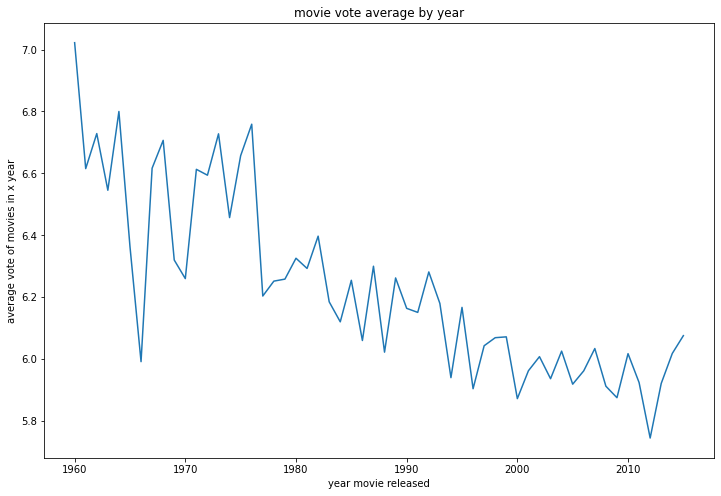

```python
year_avg_df['vote_average'].plot(kind='line',xlabel='year movie released', ylabel='average vote of movies in x year', title='movie vote average by year')
```

As more movies are released(in this dataset) the swings are not as violent, but a downward trend can definitely be observed.

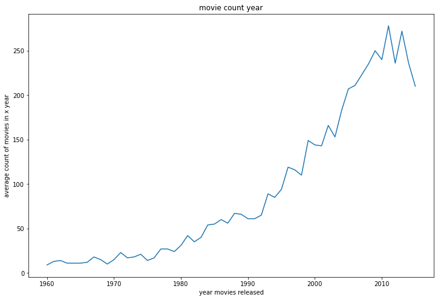

```python
year_avg_df['movie_count'].plot(kind='line',xlabel='year movies released', ylabel='average count of movies in x year', title='movie count year')
```

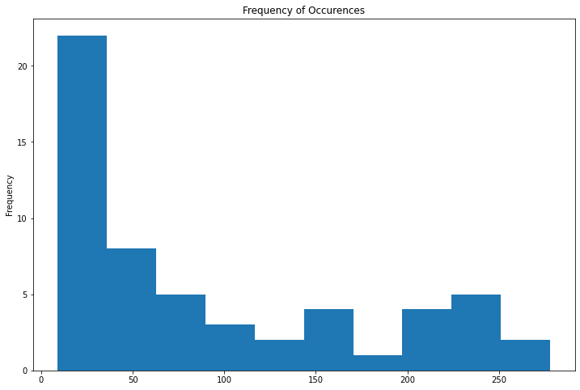

```python
year_avg_df['movie_count'].plot(kind='hist', title='Frequency of Occurences')
```

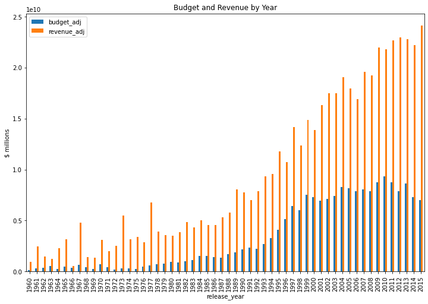

```python
movie_sums_by_year[['budget_adj','revenue_adj']].plot(kind='bar', ylabel='$ millions', title='Budget and Revenue by Year')
```

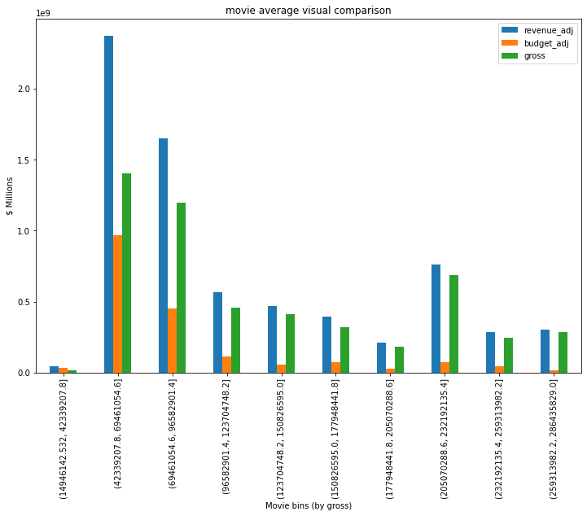

```python
movie_avgs_by_year_merged[['revenue_adj', 'budget_adj','gross']].groupby(movie_gross_bins).sum().plot(kind='bar', title='movie average visual comparison',  ylabel='$ Millions',xlabel='Movie bins (by gross)')
```

```python
print(df['budget_adj'].sort_values().nlargest(10))
```

```
2244    4.250000e+08
3375    3.683713e+08
7387    3.155006e+08
6570    2.920507e+08
5231    2.716921e+08
7394    2.713305e+08
1929    2.600000e+08
14      2.575999e+08
1389    2.541001e+08
8089    2.504192e+08
Name: budget_adj, dtype: float64
```

A sampling of some of the larger budgets, Seeing how dramatically values at the top scale

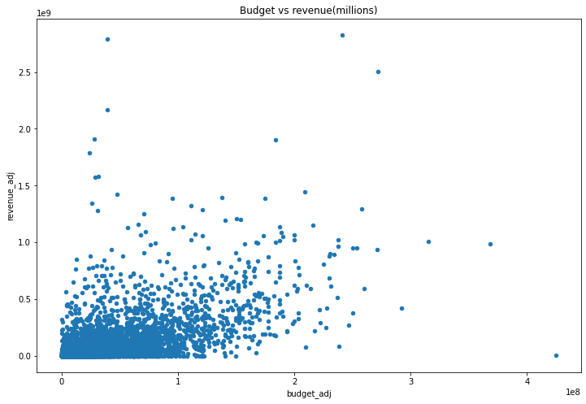

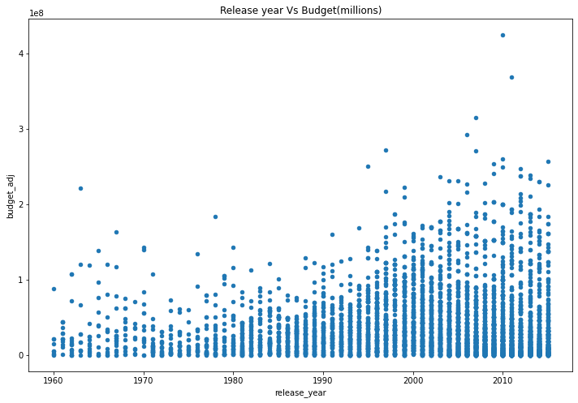

```python
df.plot(kind='scatter', x='budget_adj', y='revenue_adj', title='Budget vs revenue(millions)')
df.plot(kind='scatter', y='budget_adj', x='release_year',  title='Release year Vs Budget(millions)')
```

In millions, we can see the first graph is well-dispersed across both profitable, and profit(less).

Graph two shows a trend of increasing (adjusted)budget with time.

```python
print(top_keywords.head(10))
```

```
orcs                      0.857143
cutting the cord          0.857143
great britain             0.833333
based on graphic novel    0.833333
shield                    0.800000
wyoming                   0.800000
italo-american            0.714286
disabled                  0.700000
individual                0.681818
arms deal                 0.666667
Name: ratio, dtype: float64
```

The above data is a sampling of popular keywords, the higher the number, the more often they were found in the top 1000 popular movies.

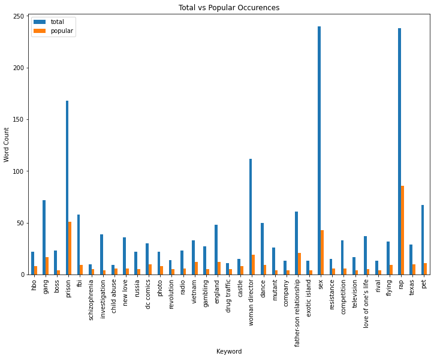

```python
keyword_slice = keyword_compare_df[['total','popular']].head(35)
keyword_slice.plot(kind='bar', title='Total vs Popular Occurences', ylabel='Word Count', xlabel = 'Keyword')
```

```python
print(year_avg_df['movie_count'].sort_values(ascending =False).nlargest(10))
print(year_avg_df.head(3))

print(year_avg_df.describe())
```

```
release_year
2011    278
2013    272
2009    250
2010    240
2014    236
2012    236
2008    235
2007    223
2006    211
2015    210
Name: movie_count, dtype: int64
              vote_average  movie_count  avg_standard_dev
release_year
1960              7.022222            9          2.700568
1961              6.615385           13          1.313324
1962              6.728571           14          1.699271
       vote_average  movie_count  avg_standard_dev
count     56.000000    56.000000      5.600000e+01
mean       6.230226    92.303571     -7.890514e-16
std        0.293270    85.096078      1.000000e+00
min        5.744915     9.000000     -1.654822e+00
25%        6.015083    18.000000     -7.335986e-01
50%        6.173398    60.500000     -1.937710e-01
75%        6.372013   150.000000      4.834700e-01
max        7.022222   278.000000      2.700568e+00
```

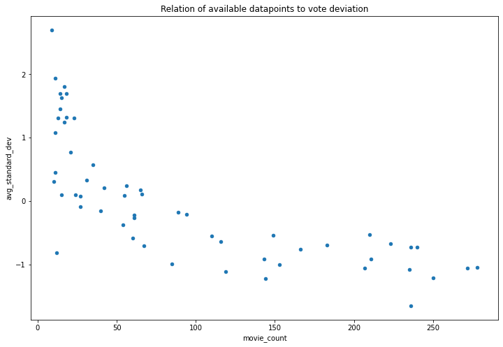

```python
year_avg_df.plot(kind='scatter', x='movie_count', y='avg_standard_dev', title='Relation of available datapoints to vote deviation')
```

A lot of volitility is likely to arise from a lack of titles to vote on during earlier years, leading to bigger swings in voting power, and lower budgets,revenues and grosses to compare. This *is* further amplified by the titles I had to remove due to lack of budget.

Once at least ane stimated 50 movies are part of the voting pool, the deviation-line becomes much tighter.

```python
print(movie_avgs_by_year_merged['gross'].sort_values(ascending =False).head(10))
```

```
release_year
1973    286435829.0
1965    244029607.0
1977    229269061.0
1967    229216137.0
1975    228357246.0
1964    184787631.0
1961    163619914.0
1970    158383468.0
1976    141497066.0
1972    136382521.0
Name: gross, dtype: float64
```

```python
print(movie_avgs_by_year_merged['ratio'].sort_values(ascending =False).head(10))
```

```
release_year
1973    17.0
1975    15.0
1972    13.0
1977    12.0
1974     9.0
1964     8.0
1961     7.0
1965     7.0
1967     7.0
1978     6.0
Name: ratio, dtype: float64
```

```python
print(movie_avgs_by_year_merged.describe())
print(movie_avgs_by_year_merged.head())
```

```
        revenue_adj    budget_adj         gross      ratio
count  5.600000e+01  5.600000e+01  5.600000e+01  56.000000
mean   1.262636e+08  3.312618e+07  9.313742e+07   4.375000
std    5.535959e+07  1.037993e+07  5.812418e+07   3.289446
min    4.743853e+07  1.112826e+07  1.521736e+07   1.000000
25%    9.174657e+07  2.588575e+07  5.706349e+07   2.000000
50%    1.105664e+08  3.184204e+07  7.050647e+07   3.000000
75%    1.372009e+08  3.913684e+07  1.110557e+08   5.000000
max    3.042226e+08  5.563933e+07  2.864358e+08  17.000000
              revenue_adj  budget_adj        gross  ratio
release_year
1960          105683296.0  18069462.0   87613834.0    6.0
1961          189509377.0  25889462.0  163619914.0    7.0
1962          106237011.0  28175832.0   78061179.0    4.0
1963          114263915.0  47466676.0   66797239.0    2.0
1964          210021920.0  25234289.0  184787631.0    8.0
```

```python
print(movie_avgs_by_year_merged['ratio'].sort_values(ascending =False))
```

```
release_year
1973    17.0
1975    15.0
1972    13.0
1977    12.0
1974     9.0
1964     8.0
1961     7.0
1965     7.0
1967     7.0
1978     6.0
1976     6.0
1960     6.0
1971     5.0
1969     5.0
```

[output cut: 43 more lines]

The extreme ratio, which I thought would be corrected by removing 0 budget movies, is still present. Many other numbers did flatten out a bit, which is useful.

```python
print(highest_1000_voted_movies[['original_title', 'vote_average']].nlargest(25, 'vote_average'))
```

```
                           original_title  vote_average
4178             The Shawshank Redemption           8.4
5986                    Guten Tag, RamÃ³n           8.4
7948                    Stop Making Sense           8.4
7269                        The Godfather           8.3
650                              Whiplash           8.2
2409                           Fight Club           8.1
2875                      The Dark Knight           8.1
3826   Kill Bill: The Whole Bloody Affair           8.1
4177                         Pulp Fiction           8.1
4179                         Forrest Gump           8.1
4946      Bones Brigade: An Autobiography           8.1
8043           Michael Jackson's Thriller           8.1
9758               The Godfather: Part II           8.1
10222                    Schindler's List           8.1
9                              Inside Out           8.0
35                                   Room           8.0
629                          Interstellar           8.0
636                    The Imitation Game           8.0
718                                 Mommy           8.0
2414                       The Green Mile           8.0
5914            One Direction: This Is Us           8.0
7309              The Empire Strikes Back           8.0
8069                   The Usual Suspects           8.0
8987                   American History X           8.0
9805      One Flew Over the Cuckoo's Nest           8.0
```

From a selection of movies, I can see that many of them are indeed 'known factors'

```python
print(year_avg_df['vote_average'].sort_values(ascending =False))
```

```
release_year
1960    7.022222
1964    6.800000
1976    6.758824
1962    6.728571
1973    6.727778
1968    6.706667
1975    6.657143
1967    6.616667
1961    6.615385
1971    6.613043
1972    6.594118
1963    6.545455
1974    6.457143
1982    6.397143
```

[output cut: 43 more lines]

The 60's and 70's dominate the top average votes the first entry post-2000 is more than halfway down the series.

```python
print(year_avg_df['vote_average'].sort_values(ascending =True).nsmallest(10))
```

```
release_year
2012    5.744915
2000    5.872222
2009    5.875200
1996    5.904202
2008    5.912340
2005    5.918841
2013    5.921324
2011    5.924101
2003    5.936601
1994    5.940000
Name: vote_average, dtype: float64
```

From the other side, nearly all of the top 10 results are post 2000

```python
print(year_avg_df['avg_standard_dev'].sort_values(ascending =False))
```

```
release_year
1960    2.700568
1964    1.942830
1976    1.802425
1962    1.699271
1973    1.696565
1968    1.624580
1975    1.455712
1967    1.317696
1961    1.313324
1971    1.305341
1972    1.240807
1963    1.074875
1974    0.773748
1982    0.569158
```

[output cut: 43 more lines]

```python
print(year_avg_df['avg_standard_dev'].sort_values(ascending =True))
```

```
release_year
2012   -1.654822
2000   -1.220728
2009   -1.210574
1996   -1.111684
2008   -1.083932
2005   -1.061768
2013   -1.053301
2011   -1.043831
2003   -1.001207
1994   -0.989618
2006   -0.914311
2001   -0.913791
1966   -0.813444
2002   -0.758325
```

[output cut: 43 more lines]

Yet again the more recent years fall below the mean of the dataset

#### Limitations

Though the dataset was relatively large, one of the primary limitations I found was since a lot of my prefered measurements involved budget, and half the values had a budget of 0 that I considered a'unlcean' factor, I had to remove half my dataset.

I would have liked those budgets filled out, and I would also have prefered to have a standardized quantity of movies per year, or perhaps per decade. The rising count per year led to some uncertainty as I was cleaning/exploring the data.

## Conclusions/Predictions

- Predict: Likely Results based on current data
- Conclude: Reasonable assumptions based on current data
- As subsequent years are added to this dataset, we will see a continued downward trend vote_average
- Certain keywords were more likely to be found in the top 1000 movies, given more data and a more *normalized* list of keywords I think that the likelihood of certain keywords would continue to rise and act as a strong correlating value for highly rated movies.

## Communicate

Used Resources:

- [Real Python](https://realpython.com/pandas-sort-python/)
- [Udacity](https://www.udacity.com/)
- [Stackoverflow](https://stackoverflow.com/)
- [A very well-done review](https://review.udacity.com/#!/reviews/2947260)